# Basit_Lab_05_RL

**Reinforcement Learning**

1. Reinforcement is the branch of machine learning.
2. RL in robotics: It focuses on robot learning and making decision through trail and error process.
3. The RL model provides feeback to the robot based on its action.

**Types of RL:**

1. Positive RL: It is defined as when an action is correct and increases reward.
2. Negative RL: When the wrong action is taking by the robot and decreases the points of reward.

**Key components of RL:**

1. **Strategy:** The strategy a robot adopts tp perform its actions based on the enviroment state.
2. **Reward function (model):** It increases or decreases based on feedback given to the robot for action performed.
3. Value function: It is the numeric representation of the reward that robot can expect.
4. Model: It is te traning stage of the bobot.

**Step 1: Importing the libraries**

```python
# general libraries
import numpy as np
import pandas as pd
# visualization libraries
import matplotlib.pyplot as plt
from matplotlib.colors import ListedColormap
```

**Step 2: Defining the Maze**

1. The maze is represented as a 2D narry (Numpy Array).
2. Zero values are safe path, and ones are obstacles that robot need to avoid.
3. Start and goal define the positions where robot begins and ends.

```python
1 # creating the maze :
maze = np.array([
    [0,1,1,1,1,1,1,1,1,1],
    [0,0,0,0,1,0,0,0,0,1],
    [1,1,1,0,1,0,1,1,0,1],
    [1,0,0,0,0,0,1,0,0,1],
    [1,0,1,1,1,1,1,0,1,1],
    [1,0,1,0,0,0,0,0,1,1],
    [1,0,1,0,1,1,1,0,1,1],
    [1,0,1,0,1,0,0,0,1,1],
    [1,0,1,0,1,0,1,0,0,1],
    [1,1,1,0,1,1,1,1,0,0]])
```

```python
# let's define the start and end points
start = (0,0)
goal = (9,9)
```

step 3: Define the RL Parameters and Initialize the Q-Table

-Let's define the RL parameters:

1. num_episodes: number of tmes the robot will attempt to navifate the maze.
2. alpha: the learning rate that controls how much new information overrides the old information.
3. gamma: discount factor giving more weight to immediate rewards.
4. epsilon: probability of exploration verus exploition.
5. rewards that are set to penalize hitting obstacles, rewar reaching the end and slightly penalize each step tp find shortest paths.
6. action define possible moves: ledt, right, up, down
7. Q is the Q-table initialized to zero; it stores expected rewards for each state-action pair.

```python
# defining the RL parameters
num_episodes = 5000
alpha = 0.1
gamma = 0.9
epsilon = 0.5
```

```python
# let's define the reward
reward_fire = -10     # hitting an obstacles
reward_goal = 50      # getting to the end of the maze
reward_step = -1      # deducting point for being late
```

```python
# let's define the actionsfor left, right, down and up
actions = [(0,-1), (0,1), (-1,0), (1,0)]
```

```python
# let's define the Q-table
Q = np.zeros(maze.shape + (len(actions),))
```

Step 4: Define the Helper Function for Maze Validity and Action Selection

1. **is_valid function** that ensure the robot can only nove inside the maze and voids obstacles.
2. **choose_action function** that implemnet exploration (rndom action) vs exploitation (best learned action)

```python
# lets define the is_valid function
def is_valid(pos):
  r,c = pos     # r stand for row and c stand for column
  if r < 0 or r >= maze.shape[0]:
    return False
  if c < 0 or c >= maze.shape[1]:
    return False
  if maze[r,c] == 1:
    return False
  return True
```

```python
# let define the hoose_action function
def choose_action(state):
  if np.random.rand() < epsilon:
    return np.random.choice(len(actions))
  else:
    return np.argmax(Q[state])
```

```python
rewards_all_episodes = []

for episode in range(num_episodes):
  state = start
  total_rewards = 0
  done = False

  while not done:
    action_index = choose_action(state)
    action = actions[action_index]

    next_state = (state[0] + action[0], state[1] + action[1])

    if not is_valid(next_state):
      reward = reward_fire
      done = True

    elif next_state == goal:
      reward = reward_goal
      done = True
    else:
      reward = reward_step

      old_value = Q[state][action_index]
      next_max = np.max(Q[next_state]) if is_valid(next_state) else 0

      Q[state][action_index] = old_value + alpha * \
      (reward + gamma * next_max - old_value)

      state = next_state
      total_rewards += reward

global epsilon
epsilon = max(0.01, epsilon * 0.995)
rewards_all_episodes.append(total_rewards)
```

**Step 5: Tranig the robot with Q-Learning Modeling**

- let's train the robot:
1. Run multiple episodes for the robot to learn.
2. During each episode, the robot select actions and updates itd Q-table using the Q-learning formula:
3. total_reward tracks cumulative rewards per episode
4. epsilon decays gradually to reduce randomness over time.

```python
rewards_all_episodes = []

for episode in range(num_episodes):
  state = start
  total_rewards = 0
  done = False

  while not done:
    action_index = choose_action(state)
    action = actions[action_index]

    next_state = (state[0] + action[0], state[1] + action[1])

    if not is_valid(next_state):
      reward = reward_fire
      done = True
    elif next_state == goal:
      reward = reward_goal
      done = True
    else:
      reward = reward_step

      old_value = Q[state][action_index]
      next_max = np.max(Q[next_state]) if is_valid(next_state) else 0

      Q[state][action_index] = old_value + alpha * \
            (reward + gamma * next_max - old_value)

      state = next_state
      total_rewards += reward

  global epsilon
  epsilon = max(0.01, epsilon * 0.995)
  rewards_all_episodes.append(total_rewards)
```

**Step t : Visualization the maze,robot path, start and End**

1. The maze and path are visualized using the calming green color.
2. The start and goal position are visually highlighted
3. The learned path is drawn clearly to demostarte

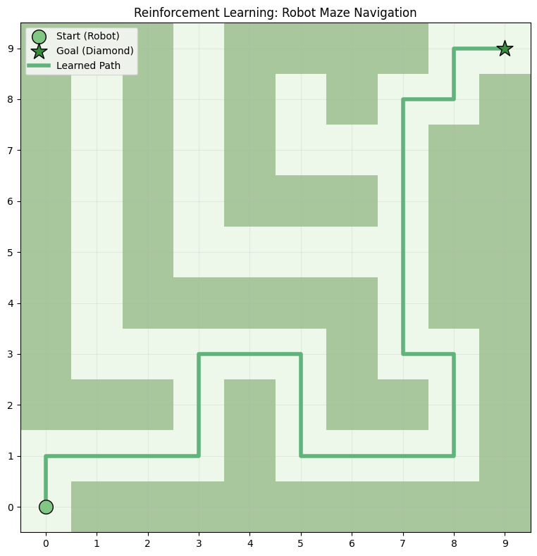

```python
def plot_maze_with_path(path):
  cmap = ListedColormap(['#eef8ea', '#a8c79c'])

  plt.figure(figsize=(8, 8))
  plt.imshow(maze, cmap=cmap)

  plt.scatter(start[1], start[0], marker='o', color='#81c784', edgecolors='black',
              s=200, label='Start (Robot)', zorder=5)
  plt.scatter(goal[1], goal[0], marker='*', color='#388e3c', edgecolors='black',
              s=300, label='Goal (Diamond)', zorder=5)

  rows, cols = zip(*path)
  plt.plot(cols, rows, color='#60b37a', linewidth=4,
           label='Learned Path', zorder=4)

  plt.title('Reinforcement Learning: Robot Maze Navigation')
  plt.gca().invert_yaxis()
  plt.xticks(range(maze.shape[1]))
  plt.yticks(range(maze.shape[0]))
  plt.grid(True, alpha=0.2)
  plt.legend()
  plt.tight_layout()
  plt.show()


plot_maze_with_path(optimal_path)
```

**Observation : As we can see, that the model successfully reached the destination by finding the right path**

Step 8: Plot Rewards per Training

- the following plot shows the robot's overall performance improve across training episode.

[figure not shown]

```python
def plot_rewards(rewards):
  plt.figure(figsize=(10, 5))
  plt.plot(rewards)
  plt.title("Total Rewards per Episode")
  plt.xlabel('Episode')
  plt.ylabel('Total Rewards')
  plt.grid(True)
  plt.show()

plot_rewards(rewards_all_episodes)
```

**Last Step: Converting notebook into HTML**